# Homework 7: Contrasts

Jamie Ash

due: 2021-10-11

```r
infile <- "..\\data\\"
meso <- read.csv(paste(infile, "leibold_mesocosm_data_subset.csv", sep = ""))
```

# 1 Linear model Nutrients and Foodweb

Create a linear model that tests whether richness is explained by nutrient level and/or food web treatment, and whether the effect of food web treatment differs between nutrient levels, while including block as a covariate. Why is including block as a covariate important? Use residual plots to decide whether it is better to model Chao-1 richness as normally or lognormally distributed. Report marginal F-tests on the model terms, and plot the fitted effects. What is your interpretation of these results

**Answer:** The block co-variate captures any variation in the data that is not explained by the predictors. If Block is significant, or produces large differences in mean values, then something is up. After producing residual plots for the lognormal and normal distribution, and performing an AIC analysis I found that the two produced relatively similar results, 240.2 (normal) and 240.8 (lognormal). I decided to go with the lognormal distribution because the domain of Species Richness is $0$ to $Inf$ (same as lognormal), but a normal distribution’s domain is $-Inf$ to $Inf$. I performed an Anova on the lognormal model and found nutrient level and food wed type to have a significant effect on species richness. I plotted the effects of the lognormal model. I ended up using a glm with a gaussian family and log link function. I’m not sure if this is equivalent to a creating a model where the species richness is a pull from a lognormal distribution. I think it is, so that’s what I went with.

```r
mod_log <- glm(Phyto_Chao1 ~ NutrientLevel + FoodWeb + FoodWeb:NutrientLevel + Block,
          data = meso, family = gaussian(link = "log"))

mod_norm <- glm(Phyto_Chao1 ~ NutrientLevel + FoodWeb + FoodWeb:NutrientLevel + Block,
          data = meso, family = gaussian(link = "identity"))
#mod3 <- glm(log(Phyto_Chao1) ~ NutrientLevel + FoodWeb + FoodWeb:NutrientLevel + Block,
#          data = meso, family = gaussian(link = "identity"))
```

## 1.1 Model Selection Anova Results

```r
AIC(mod_norm, mod_log)
```

```
##          df      AIC
## mod_norm  8 240.2121
## mod_log   8 240.8250
```

```r
Anova(mod_log, test = "F")
```

```
## Analysis of Deviance Table (Type II tests)
##
## Response: Phyto_Chao1
## Error estimate based on Pearson residuals
##
##                       Sum Sq Df F value   Pr(>F)
## NutrientLevel         149.88  1  6.5873 0.015153 *
## FoodWeb               298.17  2  6.5524 0.004119 **
## Block                   2.57  1  0.1131 0.738881
## NutrientLevel:FoodWeb  55.32  2  1.2158 0.309815
## Residuals             728.09 32
## ---
## Signif. codes:  0 '***' 0.001 '**' 0.01 '*' 0.05 '.' 0.1 ' ' 1
```

## 1.2 Plotted Model Effect

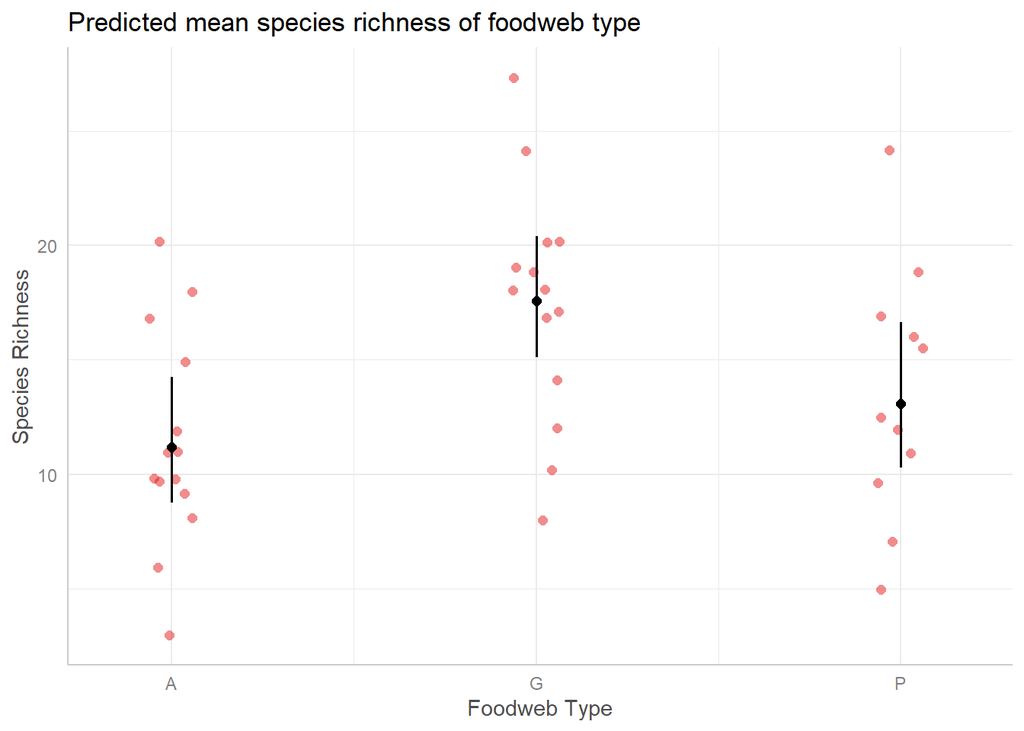

```r
plot(ggeffect(mod_log),  add = TRUE)$FoodWeb +
   labs(x = "Foodweb Type",
        y = "Species Richness",
        title = "Predicted mean species richness of foodweb type")
```

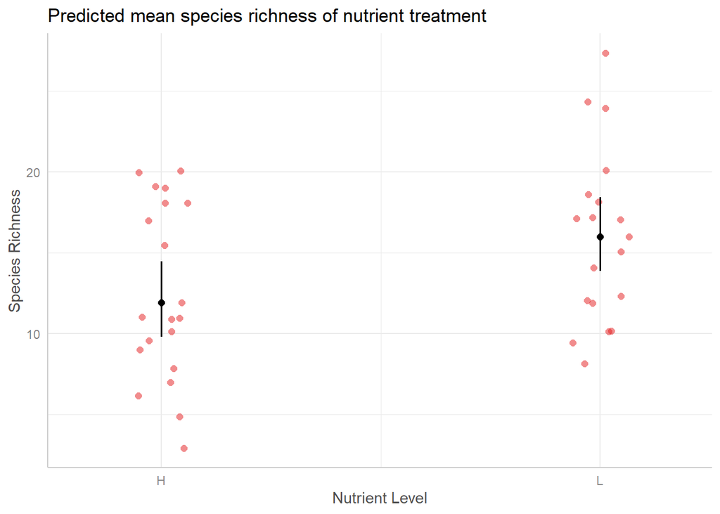

```r
plot(ggeffect(mod_log),  add = TRUE)$NutrientLevel +
  labs(x = "Nutrient Level",
       y = "Species Richness",
       title = "Predicted mean species richness of nutrient treatment")
```

## 1.3 Residuals Normal

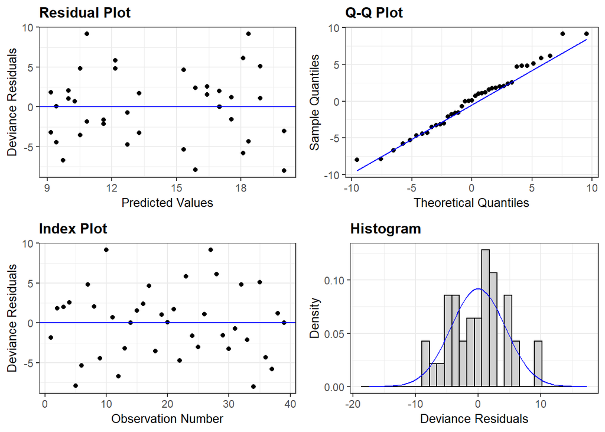

```r
resid_panel(mod_norm)
```

## 1.4 Residuals Lognormal

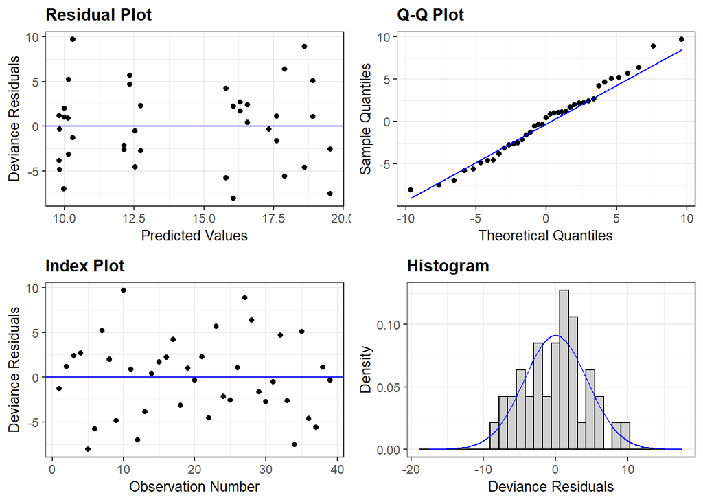

```r
resid_panel(mod_log)
```